# Proyecto_Final

Oscar Pérez 37398, ____________, ______________

2/12/2020

```r
if (!require(tidyverse)) {
    install.packages("tidyverse")
    require(tidyverse)
}
if (!require(invgamma)) {
    install.packages("invgamma")
    require(invgamma)
}
library(tidyverse)
```

## 1. Pruebas de hipótesis

De acuerdo a una encuesta en EUA, 26% de los residentes adultos de Illinois han terminado la preparatoria. Un investigador sospecha que este porcentaje es menor en un condado particular del estado. Obtiene una muestra aleatoria de dicho condado y encuentra que 69 de 310 personas en la muestra han completado la preparatoria. Estos resultados soportan su hipótesis? (describe tu elección de prueba de hipótesis, valor p y conclusión).

Hipótesis Nula: La proporción de los residentes de Illinois que han terminado la preparatoria (26%) que han terminado la preparatoria es igual que en un condado en particular.

Usaremos la prueba de Wald.

Primero calculamos un estimador de la probabilidad del condado y un estimador del error estándar

```r
p_hat <- 69 / 310
ee <- sqrt(p_hat * (1 - p_hat) / 310)
```

Calculamos la estadística W de Wald

```r
w <- (p_hat - .26) / ee
w
```

```
## [1] -1.58382
```

Calculamos el valor p a una cola porque queremos ver si es menor

```r
valor_p <-  (1 - pnorm(abs(w)))
valor_p
```

```
## [1] 0.05661737
```

## 2. Relación entre bootstrap e inferencia bayesiana

Consideremos el caso en que tenemos una única observación $x$ proveniente de una distribución normal

$$x \sim N(\theta, 1)$$

Supongamos ahora que elegimos una distribución inicial Normal.

$$\theta \sim N(0, \tau)$$

dando lugar a la distribución posterior (como vimos en la tarea).

$$\theta|x \sim N\bigg(\frac{x}{1 + 1/\tau}, \frac{1}{1+1/\tau}\bigg)$$

Ahora, entre mayor $\tau$, más se concentra la posterior en el estimador de máxima verosimilitud $\hat{\theta}=x$. En el límite, cuando $\tau \to \infty$ obtenemos una inicial no-informativa (constante) y la distribución posterior

$$\theta|x \sim N(x,1)$$

Esta posterior coincide con la distribución de bootstrap paramétrico en que generamos valores $x^*$ de $N(x,1)$, donde $x$ es el estimador de máxima verosimilitud.

Lo anterior se cumple debido a que utilizamos un ejemplo Normal pero también se cumple aproximadamente en otros casos, lo que conlleva a una correspondencia entre el bootstrap paramétrico y la inferencia bayesiana. En este caso, la distribución bootstrap representa (aproximadamente) una distribución posterior no-informartiva del parámetro de interés. Mediante la perturbación en los datos el bootstrap aproxima el efecto bayesiano de perturbar los parámetros con la ventaja de ser más simple de implementar (en muchos casos).  
*Los detalles se pueden leer en *The Elements of Statistical Learning* de Hastie y Tibshirani.

Comparemos los métodos en otro problema con el fin de apreciar la similitud en los procedimientos:

Supongamos $x_1,...,x_n \sim N(0, \sigma^2)$, es decir, los datos provienen de una distribución con media cero y varianza desconocida.

En los puntos 2.1 y 2.2 buscamos hacer inferencia del parámetro $\sigma^2$.

2.1 Bootstrap paramétrico.

- Escribe la función de log-verosimilitud y calcula el estimador de máxima verosimilitud para $\sigma^2$. Supongamos que observamos los datos `x` (en la carpeta datos), ¿Cuál es tu estimación de la varianza?

La función de log verosimilitud es:

$log(L(\sigma^2;x_1,...,x_n))= 150log(\frac{1}{{\sqrt {2\pi\sigma^2} }})+\frac{\sum_{1=1}^{150}{x_i^2}}{{{2\sigma^2} }}$

Calculamos el estimador de máxima verosimilitud:

```r
X <- as.data.frame(get(load("F:/FUNDAMENTOS/x.RData")))
summary(X)
```

```
##  get(load("F:/FUNDAMENTOS/x.RData"))
##  Min.   :-28.4225
##  1st Qu.: -7.1859
##  Median :  1.2932
##  Mean   :  0.5643
##  3rd Qu.:  8.2099
##  Max.   : 26.8635
```

```r
nrow(X)
```

```
## [1] 150
```

Calculamos el logaritmo de la verosimilitud con los datos:

```r
calc_verosim <- function(x_i){
  sumando <- -(x_i**2)
  function(sigma_cuad){
        150*log(1/(sqrt(sigma_cuad*2*pi)))+(1/(2*(sigma_cuad)))*sum(sumando)
  }
}
verosim <- calc_verosim(X)
```

Maximizamos

```r
solucion <- optimize(verosim, c(0,200), maximum = TRUE)
solucion
```

```
## $maximum
## [1] 131.291
##
## $objective
## [1] -578.647
```

Con otro método (el visto en clase)

```r
res <- optim(10, verosim, control = list(fnscale = -1, maxit = 1000), method = "BFGS")
res$par
```

```
## [1] 131.0017
```

Checamos convergencia

```r
res$convergence
```

```
## [1] 0
```

Sí converge.

Graficamos de manera ilustrativa para ver el máximo de la función de log verosiilitud

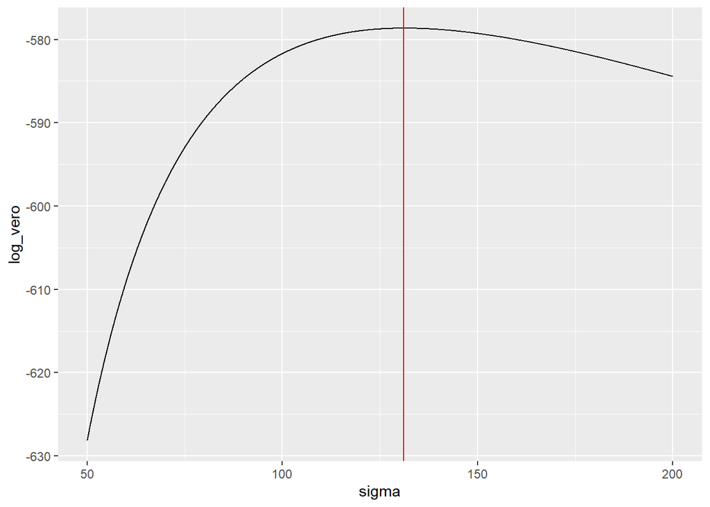

```r
dat_verosim <- tibble(sigma_cuad = seq(50, 200, 0.01)) %>% mutate(log_vero = map_dbl(sigma_cuad, verosim))
ggplot(dat_verosim, aes(x = sigma_cuad, y = log_vero)) + geom_line() + geom_vline(xintercept = res$par, color = "red") + xlab("sigma")
```

Por lo tanto el estimador de máxima verosimilitud es:

```r
sigma_cuadrada <- res$par
sigma_cuadrada
```

```
## [1] 131.0017
```

- Aproxima el error estándar de la estimación usando **bootstrap paramétrico** y realiza un histograma de las replicaciones bootstrap.

Simulamos observaciones con base en el estimador de máxima verosimilitud, del mismo número de nuestra muestra inicial

```r
simular_modelo <- function(n, sigma){
  rnorm(n, 0, sigma)
}
muestra_bootstrap <- simular_modelo(150, sigma_cuadrada^0.5)
```

Creamos nueva verosimilitud para muestra bootstrap, optimizamos y vemos si converge

```r
log_p_boot <- calc_verosim(muestra_bootstrap)

# optimizamos
res_boot <- optim(100, log_p_boot, control = list(fnscale = -1, maxit = 1000), method = "BFGS")
res_boot$convergence
```

```
## [1] 0
```

Sí converge, el estimador de máxima verosimilitud para esta única replicación bootstrap es:

```r
est_mle_boot <- res_boot$par
est_mle_boot
```

```
## [1] 147.9346
```

Esto lo hacemos 5000 veces

```r
rep_boot <- function(rep, calc_verosim, sigma_cuadrada, n){
  muestra_bootstrap <- simular_modelo(150, sigma_cuadrada^0.5)
  log_p_boot <- calc_verosim(muestra_bootstrap)
  # optimizamos
  res_boot <- optim(10, log_p_boot, control = list(fnscale = -1, maxit = 1000), method = "BFGS")
  try(if(res_boot$convergence != 0) stop("No se alcanzó convergencia."))
  tibble(parametro = c("sigma_cuad"), estimador_boot = res_boot$par)
}

set.seed(127876)

reps_boot <- map_dfr(1:5000, ~ rep_boot(.x, calc_verosim, sigma_cuadrada, n = 150), rep = ".id")
reps_boot
```

```
## # A tibble: 5,000 x 2
##    parametro  estimador_boot
##    <chr>               <dbl>
##  1 sigma_cuad           144.
##  2 sigma_cuad           141.
##  3 sigma_cuad           110.
##  4 sigma_cuad           128.
##  5 sigma_cuad           119.
##  6 sigma_cuad           133.
##  7 sigma_cuad           119.
##  8 sigma_cuad           150.
##  9 sigma_cuad           143.
## 10 sigma_cuad           156.
## # ... with 4,990 more rows
```

Calculamos Error Estándar

```r
error_est <- sd(reps_boot$estimador_boot)
error_est
```

```
## [1] 15.09239
```

Hacemos un histograma de las sigmas cuadradas bootstrap

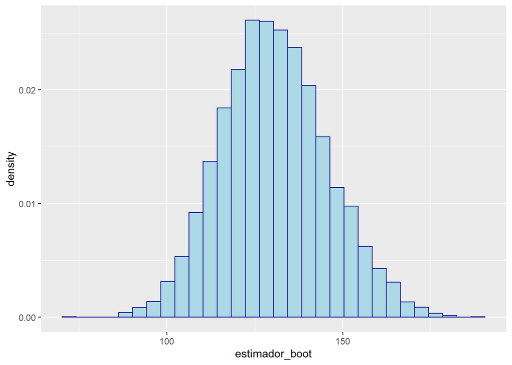

```r
ggplot(reps_boot, aes(x=estimador_boot, y = ..density..))+ geom_histogram(color="darkblue", fill="lightblue")
```

2.2 Análisis bayesiano

- Continuamos con el problema de hacer inferencia de $\sigma^2$. Comienza especificando una inicial Gamma Inversa, justifica tu elección de los parámetros de la distribución inicial y grafica la función de densidad.

Estimaremos los parámetros mediante el método de momentos, para eso obtenemos la media y la desviación estándar de las replicaciones bootstrap:

Si x es gamma inversa, entonces:

$f(x)=\frac{\beta^\alpha}{\Gamma(\alpha)}x^{-\alpha-1}exp(\frac{-\beta}{x})$

La media es:

$E(x)=\frac{\beta}{\alpha-1}$

Y la varianza es:

$Var(x)=\frac{\beta^2}{(\alpha-1)^2(\alpha-2)}$

Por lo que

$\beta=E(x)(\alpha-1)$

y

$\alpha = \frac{E(x)^2}{\sigma^2}+2$

Para parametrizar en R, tomamos

$\alpha=shape$

$\beta=rate$

Resolvemos estos parámetros

```r
mean(reps_boot$estimador_boot)
```

```
## [1] 130.68
```

```r
error_est**2
```

```
## [1] 227.7803
```

```r
shape_boot <- ((mean(reps_boot$estimador_boot)^2)/(error_est**2))+2
rate_boot <- mean(reps_boot$estimador_boot)*(shape_boot-1)

shape_boot
```

```
## [1] 76.97257
```

```r
rate_boot
```

```
## [1] 9928.099
```

Graficamos la función de densidad:

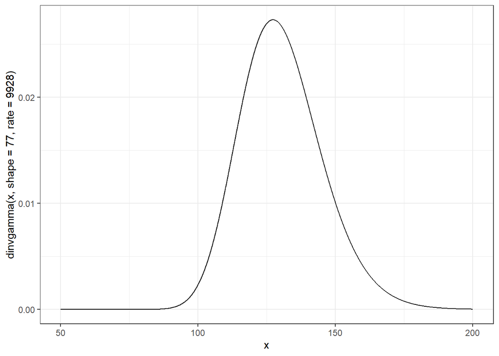

```r
library(invgamma)
library(ggplot2); theme_set(theme_bw())
x <- seq(50, 200, .01)
qplot(x, dinvgamma(x, shape = 77, rate = 9928), geom = "line")
```

Observese que es similar al histograma de las replicaciones bootstrap

- Calcula analíticamente la distribución posterior.

Tomamos como verosimilitud

$P(x_1,x_2,...x_150|\sigma^2)=\frac{(\sigma^2)^{-\frac{150}{2}}}{\sqrt{2\pi}^{150}}\exp(-\frac{\sum_{1=1}^{150}{x_i}}{2\sigma^2})$

Por otro lado:

$P(\sigma^2)=\frac{\beta^\alpha}{\Gamma(\alpha)}(\sigma^2)^{{-\alpha-1}}\exp(\frac{-\beta}{\sigma^2})$

Calculamos la posterior como:

$P(\sigma^2|x_1,x_2,...,x_150)\propto\frac{(\sigma^2)^{-\frac{150}{2}}}{\sqrt{2\pi}^{150}}\exp(-\frac{\sum_{1=1}^{150}{x_i}}{2\sigma^2})\frac{\beta^\alpha}{\Gamma(\alpha)}(\sigma^2)^{{-\alpha-1}}\exp(\frac{-\beta}{\sigma^2})$

Eliminando los términos que no dependen de $\sigma^2$:

$P(\sigma^2|x_1,x_2,...,x_150)\propto(\sigma^2)^{{-(\alpha+75)-1}}\exp(-\frac{\frac{\sum_{1=1}^{150}{x_i}}{2}}{\sigma^2})$

Por lo que $sigma^2\sim GammaInversa(\alpha+75,\frac{\frac{\sum_{1=1}^{150}{x_i}}{2}}{\sigma^2})$

La distribución posterior es gamma_inversa con shape_new, rate_new.

```r
suma_x_cuad <- function(x_i){
  sumando <- sum(x_i**2)
}
suma_x_cuad_val <- suma_x_cuad(X)

shape_new <- shape_boot+75
rate_new <- (suma_x_cuad_val + 2*rate_boot)/2

shape_new
```

```
## [1] 151.9726
```

```r
rate_new
```

```
## [1] 19774.92
```

- Realiza un histograma de simulaciones de la distribución posterior y calcula el error estándar de la distribución.

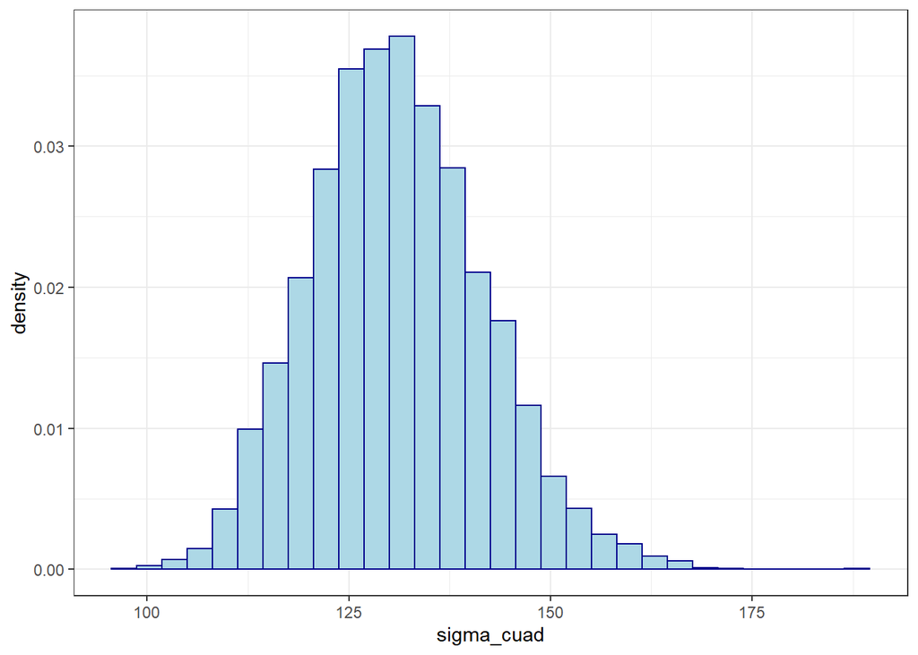

```r
simulaciones <- tibble(simul = 1:5000, sigma_cuad = rinvgamma(5000, shape_new, rate_new))
ggplot(simulaciones, aes(x=sigma_cuad, y = ..density..))+ geom_histogram(color="darkblue", fill="lightblue")
```

- ¿Cómo se comparan tus resultados con los de bootstrap paramétrico?

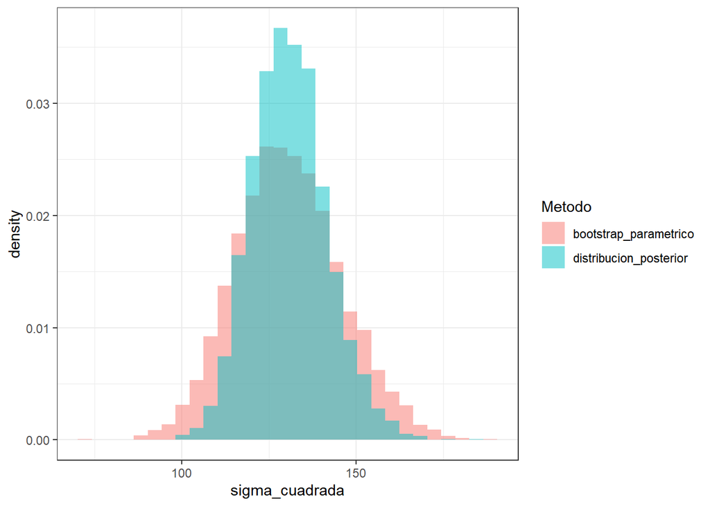

```r
histo_comparativo <- tibble(est = 1:5000, bootstrap_parametrico = reps_boot$estimador_boot, distribucion_posterior = rinvgamma(5000, shape_new, rate_new))

histo_comparativo_long <- histo_comparativo %>% pivot_longer(cols=c(2,3), names_to = "Metodo", values_to= "sigma_cuadrada")

ggplot(histo_comparativo_long, aes(sigma_cuadrada, fill = Metodo)) +
   geom_histogram(alpha = 0.5, aes(y = ..density..), position = 'identity')
```

Media de las replicaciones bootstrap

```r
mean(histo_comparativo$bootstrap_parametrico)
```

```
## [1] 130.68
```

Media de la distribución posterior

```r
mean(histo_comparativo$distribucion_posterior)
```

```
## [1] 130.9862
```

Error Estándar replicaciones bootstrap

```r
sd(histo_comparativo$bootstrap_parametrico)
```

```
## [1] 15.09239
```

Error estandar distribución posterior

```r
sd(histo_comparativo$distribucion_posterior)
```

```
## [1] 10.76147
```

Se dismuniye el error estándar de la distribucuón posterior

2.3 Supongamos que ahora buscamos hacer inferencia del parámetro $\tau=log(\sigma)$, ¿cuál es el estimador de máxima verosimilitud?

- Utiliza bootstrap paramétrico para generar un intervalo de confianza del 95% para el parámetro $\tau$ y realiza un histograma de las replicaciones bootstrap.

Haciendo:

$\tau=log(\sigma)$

o

$\sigma=exp(\tau)$

o bien

$\sigma^2=exp(2\tau)$

Y repitiendo los desarrollos anteriores:

```r
calc_verosim_tau <- function(x_i){
  sumando <- -(x_i**2)
  function(tau){
        150*log(1/(sqrt(2*pi)))+((1/(2*(exp(2*tau))))*sum(sumando))-150*tau
  }
}
verosim_tau <- calc_verosim_tau(X)
```

Maximizamos

```r
solucion_tau <- optimize(verosim_tau, c(0,20), maximum = TRUE)
solucion_tau
```

```
## $maximum
## [1] 2.438726
##
## $objective
## [1] -578.647
```

Con otro método

```r
res_tau <- optim(10, verosim_tau, control = list(fnscale = -1, maxit = 1000), method = "BFGS")
res_tau$par
```

```
## [1] 2.438813
```

Checamos convergencia

```r
res_tau$convergence
```

```
## [1] 0
```

Graficamos

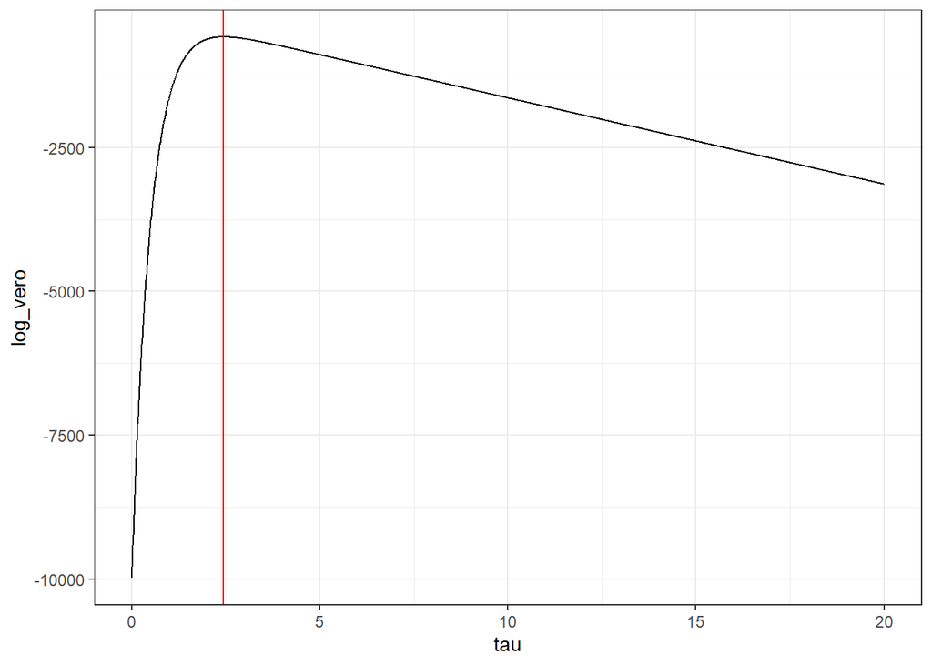

```r
dat_verosim_tau <- tibble(tau = seq(0, 20, 0.01)) %>% mutate(log_vero = map_dbl(tau, verosim_tau))
ggplot(dat_verosim_tau, aes(x = tau, y = log_vero)) + geom_line() + geom_vline(xintercept = 2.43, color = "red") + xlab("tau")
```

Simulamos observaciones con base en el estimador de máxima verosimilitud, del mismo número de nuestra muestra inicial

```r
simular_modelo_tau <- function(n, tau){
  rnorm(n, 0, tau)
}
muestra_bootstrap_tau <- simular_modelo(150, exp(2.43))
```

Creamos nueva verosimilitud para muestra bootstrap, optimizamos y vemos si converge

```r
log_p_boot_tau <- calc_verosim_tau(muestra_bootstrap_tau)
# optimizamos
res_boot_tau <- optim(10, log_p_boot_tau, control = list(fnscale = -1, maxit = 1000), method = "BFGS")
res_boot_tau$convergence
```

```
## [1] 0
```

Sí converge, el estimador de máxima verosimilitud para esta réplica bootstrap es:

```r
est_mle_boot_tau <- res_boot_tau$par
est_mle_boot_tau
```

```
## [1] 2.511417
```

Esto lo hacemos 5000 veces

```r
rep_boot_tau <- function(rep, calc_verosim_tau, tau, n){
  muestra_bootstrap_tau <- simular_modelo_tau(150, exp(res_tau$par))
  log_p_boot_tau <- calc_verosim_tau(muestra_bootstrap_tau)
  # optimizamos
  res_boot_tau <- optim(10, log_p_boot_tau, control = list(fnscale = -1, maxit = 1000), method = "BFGS")
  try(if(res_boot_tau$convergence != 0) stop("No se alcanzó convergencia."))
  tibble(parametro = c("tau"), estimador_boot_tau = res_boot_tau$par)
}

set.seed(127876)

reps_boot_tau <- map_dfr(1:5000, ~ rep_boot_tau(.x, calc_verosim_tau, tau, n = 150), rep = ".id")
reps_boot_tau
```

```
## # A tibble: 5,000 x 2
##    parametro estimador_boot_tau
##    <chr>                  <dbl>
##  1 tau                     2.49
##  2 tau                     2.48
##  3 tau                     2.35
##  4 tau                     2.43
##  5 tau                     2.39
##  6 tau                     2.45
##  7 tau                     2.39
##  8 tau                     2.51
##  9 tau                     2.48
## 10 tau                     2.53
## # ... with 4,990 more rows
```

```r
error_est_tau <- sd(reps_boot_tau$estimador_boot_tau)
error_est_tau
```

```
## [1] 0.05812505
```

Hacemos un histograma de las tau bootstrap

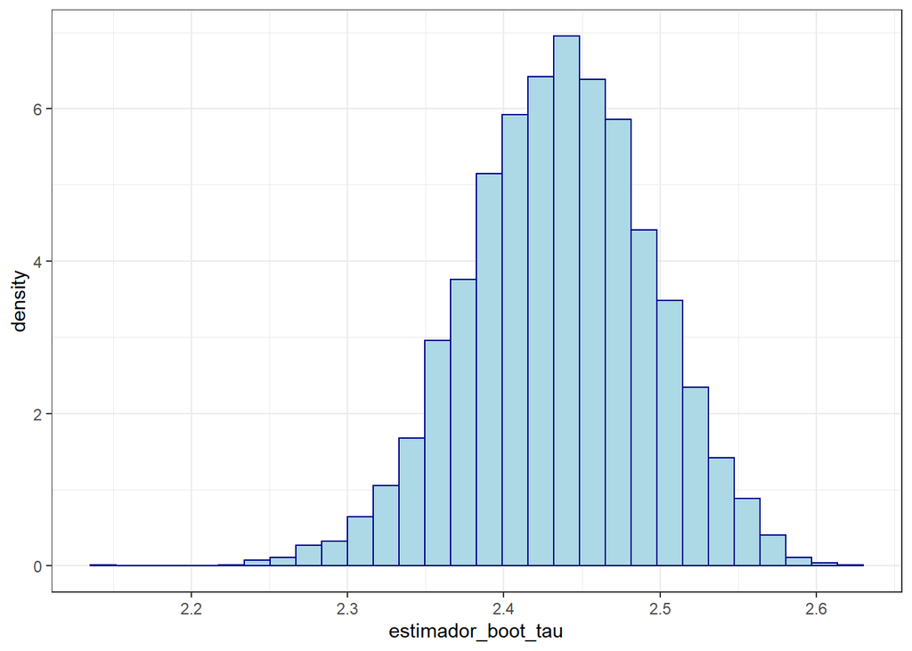

```r
ggplot(reps_boot_tau, aes(x=estimador_boot_tau, y = ..density..))+ geom_histogram(color="darkblue", fill="lightblue")
```

```r
quantile(reps_boot_tau$estimador_boot_tau, c(.025, .925))
```

```
##     2.5%    92.5%
## 2.317974 2.517961
```

- Ahora volvamos a inferencia bayesiana, calcula un intervalo de confianza para $\tau$ y un histograma de la distribución posterior de $\tau$.

```r
shape_boot_tau <- ((mean(reps_boot_tau$estimador_boot_tau)^2)/(error_est_tau**2))+2
rate_boot_tau <- mean(reps_boot_tau$estimador_boot_tau)*(shape_boot_tau-1)

shape_boot_tau
```

```
## [1] 1757.545
```

```r
rate_boot_tau
```

```
## [1] 4277.881
```

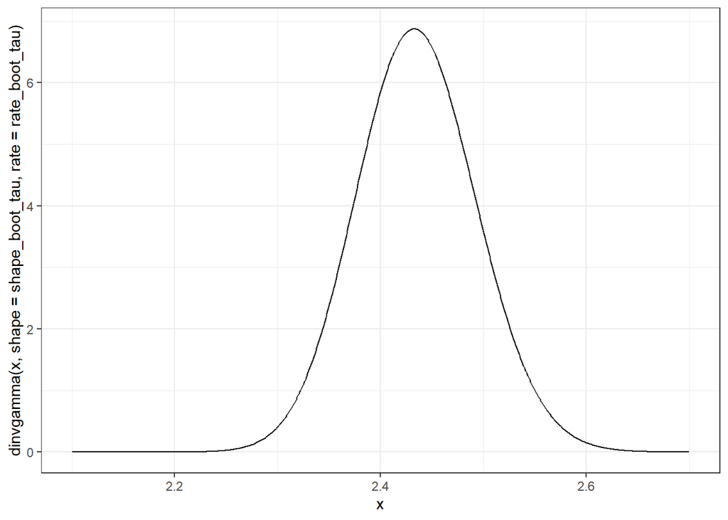

```r
x <- seq(2.1, 2.7, .001)
qplot(x, dinvgamma(x, shape = shape_boot_tau, rate = rate_boot_tau), geom = "line")
```

Tomamos la misma posterior para v=exp(2*tau), esto es tau=log(v)/2

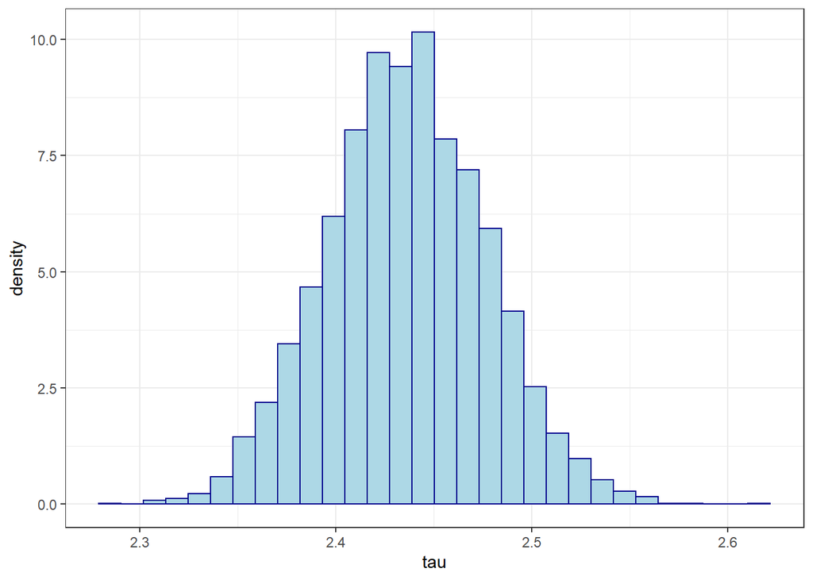

```r
simulaciones_tau <- tibble(simul = 1:5000, tau = log(rinvgamma(5000, shape_new, rate_new)))/2
ggplot(simulaciones_tau, aes(x=tau, y = ..density..))+ geom_histogram(color="darkblue", fill="lightblue")
```

Sacamos intervalo de confianza

```r
quantile(simulaciones_tau$tau, c(.025, .925))
```

```
##     2.5%    92.5%
## 2.357755 2.494553
```

### 3. Bayesiana y regularización

Lee el ejempo *2.7 Informative prior distribution for cancer rates* del libro [Bayesian Data Analysis](http://www.stat.columbia.edu/~gelman/book/BDA3.pdf) (página 46).

En el siguiente ejercicio harás algo similar al ejemplo anterior, en este caso con el modelo Beta-Binomial.

Los datos *pew_research_center_june_elect_wknd_data.dta* tienen información de encuestas realizadas durante la campaña presidencial 2008 de EUA.

```r
poll_data <- foreign::read.dta("F:/FUNDAMENTOS/pew_research_center_june_elect_wknd_data.dta")
```

- Estima el porcentaje de la población de cada estado (excluyendo Alaska, Hawai, y DC) que se considera *very liberal*, utilizando el estimador de máxima verosimilitud.

```r
por_estado <- poll_data %>% group_by(state) %>% summarise(n_estado = n())
por_estado_liberal <- poll_data %>% group_by(state,ideo) %>% summarise(n_very_liberal = n()) %>% filter(ideo=="very liberal")
por_very_liberal <- left_join(por_estado,por_estado_liberal)
por_very_liberal$por <- por_very_liberal$n_very_liberal/por_very_liberal$n_estado
por_very_liberal <- por_very_liberal %>% select(state,n_estado,n_very_liberal,por) %>% filter(state != "alaska" & state != "hawaii" & state!= "washington dc" )
por_very_liberal
```

```
## # A tibble: 48 x 4
##    state       n_estado n_very_liberal    por
##    <fct>          <int>          <int>  <dbl>
##  1 alabama          624             30 0.0481
##  2 arizona          542             28 0.0517
##  3 arkansas         307              7 0.0228
##  4 california      2854            179 0.0627
##  5 colorado         468             27 0.0577
##  6 connecticut      395             14 0.0354
##  7 delaware         119              7 0.0588
##  8 florida         1747             65 0.0372
##  9 georgia         1023             42 0.0411
## 10 idaho            140             14 0.1
## # ... with 38 more rows
```

- Grafica en el eje *x* el número de encuestas para cada estado y en el eje *y* la estimación de máxima verosimilitud. ¿Qué observas?
- Grafica en el eje *x* el porcentaje de votos que obtuvo Obama en la elección para cada estado y en el eje *y* la estimación de máxima verosimilitud. ¿Qué observas? (usa los datos *2008ElectionResult.csv*)
- Estima el mismo porcentaje usando inferencia bayesiana, en particular la familia conjugada binomial-beta. Deberás estimar la proporción de manera independiente para cada estado, sin embargo, utilizarás la misma inicial a lo largo de todos.
  - Para elegir los parámetros $\alpha$, $\beta$ de la incial considera la media y varianza de la distribución predictiva posterior (que en este caso tiene ditsribución [Beta-Binomial](https://en.wikipedia.org/wiki/Beta-binomial_distribution)) y empata la media y varianza observadas a sus valores observados para después depejar $\alpha$ y $\beta$ (puedes usar [Wolfram alpha](https://www.wolframalpha.com/) para resolver).
  - Utiliza la media posterior de cada estado como estimador puntual y repite las gráficas del inciso anterior.

**Nota:** Este proceso para obtener los parámetros de la incial es razonable para este ejercicio, sin embargo, un modelo jerárquico sería la manera de formalizar este acercamiento y se estudiará en próximas materias.